# Reprezentare grafuri

## Grafuri neorientate

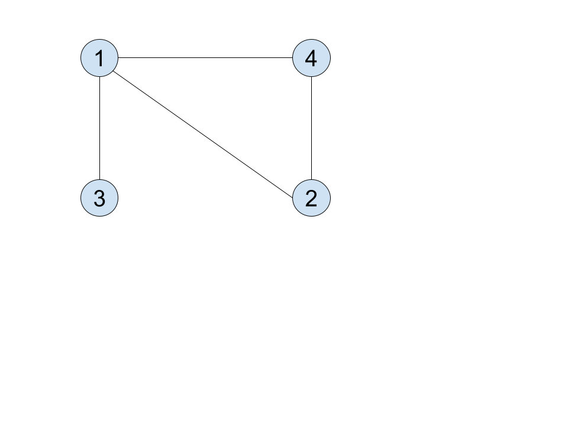

## Matrice de adiacenta

Contine pentru fiecare pereche de noduri din graf un indicator binar care indica daca intre cele doua noduri exista sau nu o muchie.

Daca intre nodul i si nodul j exista o muchie in graf, atunci `m[i][j] = 1`.

Astfel, fiecare rand i (sau coloana i) al matricei gasim pe pozitiile j unde este valoarea 1, nodurile j care au o muchie cu i.

```python
m=[
    [0,1,1,1],
    [1,0,0,1],
    [1,0,0,0],
    [1,1,0,0],
  ]
```

## Vector de noduri si muchii

Alternativ, putem reprezenta un graf listand explicit nodurile si muchiile (ca tupluri - perechi de noduri).

```python
graf={
    "noduri": [1,2,3,4],
    "muchii": [(1,2), (1,3), (1,4), (2,1), (2,4), (3,1),(4,1),(4,2)]
}
```

## Liste de vecini

In locul matricei de adiacenta putem folosi un dictionar pentru a retine listele de vecini / noduri adiacente (noduri cu care exista muchii) pentru fiecare nod.

```python
graf={
    1: [2,3,4],
    2: [1, 4],
    3: [1],
    4: [1, 2]
}
```

Exercitiu: desenati (pe o foaie, etc) graful reprezentat in celula de mai jos.

```python
graf={
    1: [2,3],
    2: [1, 3, 5],
    3: [1],
    4: [1, 2]
}
```

Nodurile pot fi reprezentate implicit prin indici (ca mai sus), sau pot avea asociate niste nume mai descriptive.

Daca nu primim informatii suplimentare despre numele nodurilor, putem presupune ca nodului x ii corespunde randul/coloana x-1 in matricea de adiacenta. (randul/coloana 0 din matricea de adiacenta ii corespunde nodului 1, etc.)

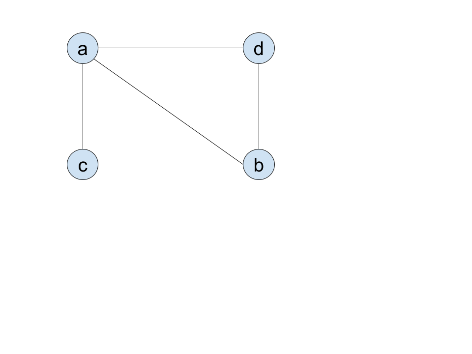

```python
graf={
    'a': ['b','c','d'],
    'b': ['a', 'd'],
    'c': ['a'],
    'd': ['a', 'b']
}
```

```python
m = [
    [0,1,1,1],
    [1,0,0,1],
    [1,0,0,0],
    [1,1,0,0],
  ]
nodes = ['a', 'b', 'c', 'd']
```

**Lant elementar** Un lant in care nodurile sunt distincte doua cate doua (nu avem doua noduri identice in lant). De exemplu, 1,4,2 este lant elementar.

**Lant neelementar** un lant care nu este elementar 😊. De exemplu, lantul 3,1,2,4,1 este neelementar.

**Lant simplu** un lant in care nu se repeta nicio muchie. Ambele lanturi de mai sus sunt simple.

**Lant compus** un lant care nu este simplu 😊. De exemplu, lantul 3,1,2,4,1,2 este compus.

**Ciclu** multime ordonata de noduri dintre care oricare doua noduri de pe pozitii consecutive sunt capete ale unei muchii din graf si in plus, exista o muchie intre primul si ultimul nod.

**Lungimea unui lant** (respectiv a unui ciclu) numarul de muchii din componenta lui. De exemplu, 1,4,2 are lungime 2.

**Ciclu elementar** Un ciclu in care nodurile sunt distincte doua cate doua (nu avem doua noduri identice in ciclu). De exemplu, 1,2,4,1 este ciclu elementar:

## Grafuri orientate

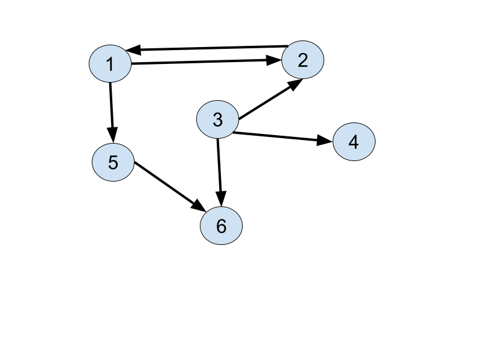

Care vor fi diferentele fata de grafurile neorientate pentru fiecare dintre cele 3 moduri de reprezentare?

```python
mo = [ [0,1,0,0,1,0],
       [1,0,0,0,0,0],
       [0,1,0,1,0,1],
       [0,0,0,0,0,0],
       [0,0,0,0,0,1],
       [0,0,0,0,0,0]
    ]
```

```python
grafo={
    "noduri": [1,2,3,4,5,6],
    "muchii": [(1,2), (1,5), (2,1), (3,2), (3,4), (3,6),(5,6)]
}
```

```python
graf_o={
    1: [2, 5],
    2: [1],
    3: [2, 4, 6],
    4: [],
    5: [6],
    6: []
}
```

**Drum** multime ordonata de noduri dintre care pentru orice pereche de doua noduri de pe pozitii consecutive avem un arc care porneste din primul nod din pereche catre al doilea nod din pereche. De exemplu, 1,5,6 in graful G formeaza un drum.